# R Markdown Peer Assessment

### Loading and preprocessing the data

Show any code that is needed to load and process data Load the data (i.e. read.csv())

```r
        data<-read.csv("activity.csv")
        str(data)
```

```
## 'data.frame':    17568 obs. of  3 variables:
##  $ steps   : int  NA NA NA NA NA NA NA NA NA NA ...
##  $ date    : Factor w/ 61 levels "2012-10-01","2012-10-02",..: 1 1 1 1 1 1 1 1 1 1 ...
##  $ interval: int  0 5 10 15 20 25 30 35 40 45 ...
```

**Process/transform the data (if necessary) into a format suitable for your analysis**

```r
       data$date<-as.Date(data$date, format="%Y-%m-%d")
        str(data)
```

```
## 'data.frame':    17568 obs. of  3 variables:
##  $ steps   : int  NA NA NA NA NA NA NA NA NA NA ...
##  $ date    : Date, format: "2012-10-01" "2012-10-01" ...
##  $ interval: int  0 5 10 15 20 25 30 35 40 45 ...
```

### What is mean total number of steps taken per day?

**Re-org data:**

```r
       # Vector - total number of steps:
total<-tapply(data$steps, data$date, function(x)sum(x))
head(total)
```

```
## 2012-10-01 2012-10-02 2012-10-03 2012-10-04 2012-10-05 2012-10-06
##         NA        126      11352      12116      13294      15420
```

```r
totalsteps<-array(NA, c(length(total),1))
for(i in 1:length(total)){
    totalsteps[i]<-total[[i]]
}
head(totalsteps)
```

```
##       [,1]
## [1,]    NA
## [2,]   126
## [3,] 11352
## [4,] 12116
## [5,] 13294
## [6,] 15420
```

```r
# Vector - days:
date_steps<-c(unique(data$date))
head(date_steps)
```

```
## [1] "2012-10-01" "2012-10-02" "2012-10-03" "2012-10-04" "2012-10-05"
## [6] "2012-10-06"
```

```r
# Double-check type = Date:
str(date_steps)
```

```
##  Date[1:61], format: "2012-10-01" "2012-10-02" "2012-10-03" "2012-10-04" ...
```

```r
# ok!

# Create new data frame:
totalsteps_frame<-data.frame(date_steps,totalsteps)
str(totalsteps_frame)
```

```
## 'data.frame':    61 obs. of  2 variables:
##  $ date_steps: Date, format: "2012-10-01" "2012-10-02" ...
##  $ totalsteps: int  NA 126 11352 12116 13294 15420 11015 NA 12811 9900 ...
```

**Using ggplot2 make a histogram:**

```
## stat_bin: binwidth defaulted to range/30. Use 'binwidth = x' to adjust this.
```

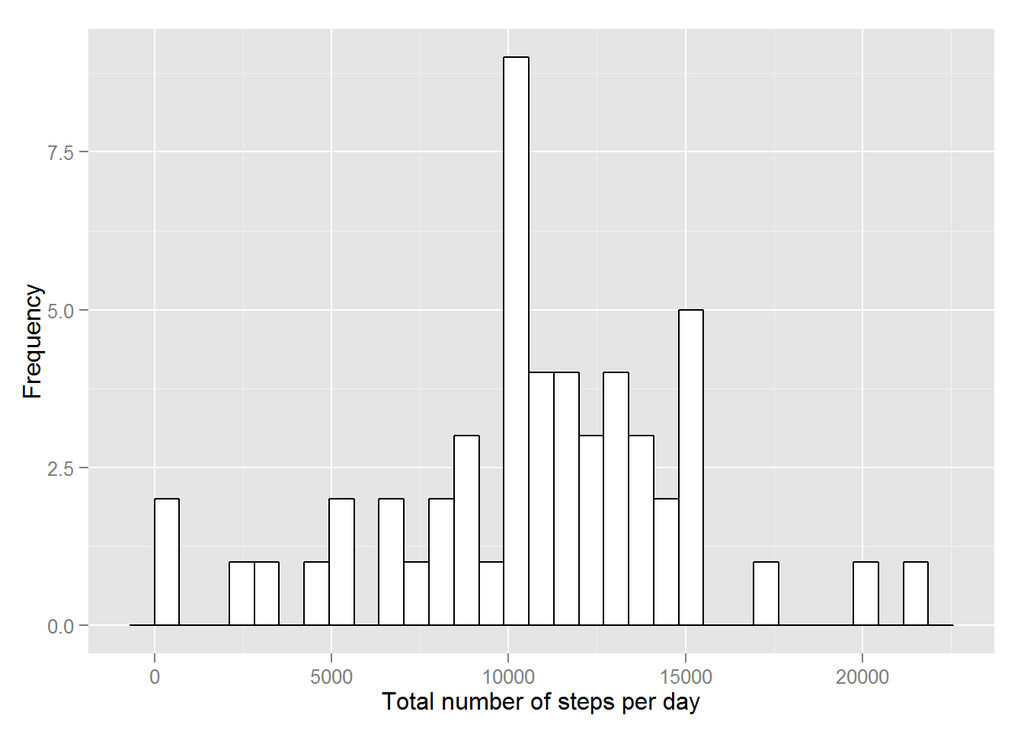

```r
        library("ggplot2")
        ggplot(aes(x=totalsteps), data=totalsteps_frame)+
        geom_histogram(color="black", fill="white") + ylab("Frequency") + xlab("Total number of steps per day")
```

### Calculate and report the mean and median total number of steps taken per day:

```r
        mean(totalsteps_frame$totalsteps, na.rm=T)
```

```
## [1] 10766
```

```r
        median(totalsteps_frame$totalsteps, na.rm=T)
```

```
## [1] 10765
```

### What is the average daily activity pattern?

### Make a time series plot (i.e. type = “l”) of the 5-minute interval (x-axis) and the average number of steps taken averaged across all days (y-axis)

```r
# Get average per interval:
        averages<-tapply(data$steps, data$interval, function(x)mean(x, na.rm=T))
        meansteps_interval<-array(NA, c(length(averages),1))
        for(i in 1:length(averages)){
            meansteps_interval[i]<-averages[[i]]
        }
        head(meansteps_interval)
```

```
##         [,1]
## [1,] 1.71698
## [2,] 0.33962
## [3,] 0.13208
## [4,] 0.15094
## [5,] 0.07547
## [6,] 2.09434
```

```r
# Vector - interval:
        interval<-unique(data$interval)
        str(interval)
```

```
##  int [1:288] 0 5 10 15 20 25 30 35 40 45 ...
```

```r
# Create new dataset:
        interval_frame<-data.frame(meansteps_interval, interval)
        str(interval_frame)
```

```
## 'data.frame':    288 obs. of  2 variables:
##  $ meansteps_interval: num  1.717 0.3396 0.1321 0.1509 0.0755 ...
##  $ interval          : int  0 5 10 15 20 25 30 35 40 45 ...
```

**Plot the time series:**

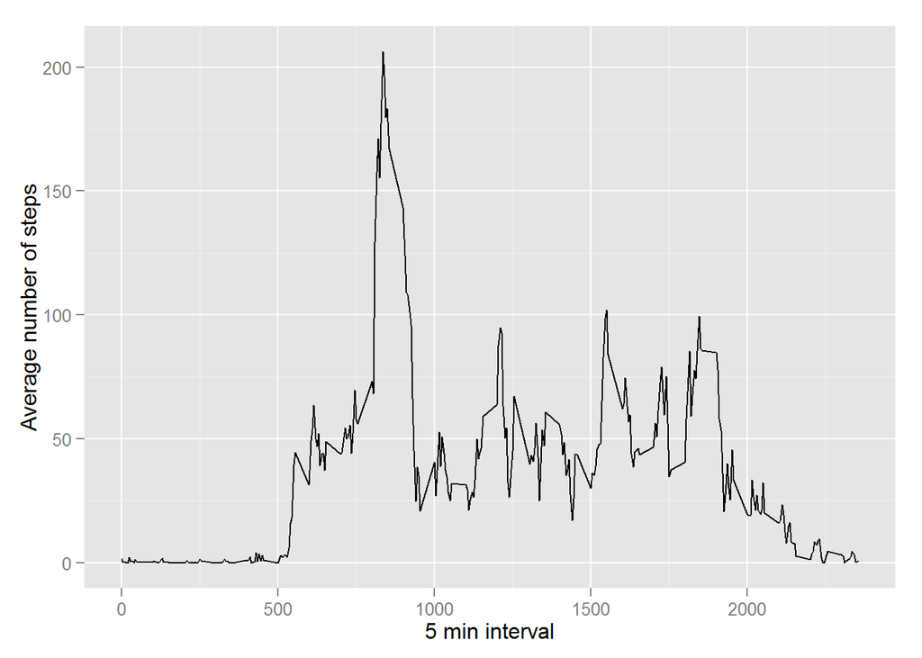

```r
        ggplot(aes(x=interval, y=meansteps_interval), data=interval_frame)+
        geom_line() + xlab("5 min interval")+ylab("Average number of steps")
```

### Which 5-minute interval, on average across all the days in the dataset, contains the maximum number of steps?

```r
        (d<-interval_frame$interval[max(interval_frame$meansteps_interval)])
```

[output not shown]

### Calculate and report the total number of missing values in the dataset (i.e. the total number of rows with NAs)

```r
missing<-which(is.na(data$steps)==T)
length(missing)
```

```
## [1] 2304
```

### Number of missing N/a’s:

**Devise a strategy for filling in all of the missing values in the dataset. The strategy does not need to be sophisticated. For example, you could use the mean/median for that day, or the mean for that 5-minute interval, etc.**

```r
# New vector:
steps2<-data$steps
steps2[is.na(steps2)==T]<-mean(data$steps, na.rm=T)
str(steps2)
```

```
##  num [1:17568] 37.4 37.4 37.4 37.4 37.4 ...
```

**Create a new dataset that is equal to the original dataset but with the missing data filled in.**

```r
        data2<-data
        data2$steps<-steps2
        str(data2)
```

```
## 'data.frame':    17568 obs. of  3 variables:
##  $ steps   : num  37.4 37.4 37.4 37.4 37.4 ...
##  $ date    : Date, format: "2012-10-01" "2012-10-01" ...
##  $ interval: int  0 5 10 15 20 25 30 35 40 45 ...
```

### Make a histogram of the total number of steps taken each day and Calculate and report the mean and median total number of steps taken per day. Do these values differ from the estimates from the first part of the assignment? What is the impact of imputing missing data on the estimates of the total daily number of steps?

```r
# Vector - total number of steps:
        total2<-tapply(data2$steps, data2$date, function(x)sum(x))
        totalsteps2<-array(NA, c(length(total2),1))
        for(i in 1:length(total2)){
            totalsteps2[i]<-total2[[i]]
        }
        head(totalsteps2)
```

```
##       [,1]
## [1,] 10766
## [2,]   126
## [3,] 11352
## [4,] 12116
## [5,] 13294
## [6,] 15420
```

```r
# Vector - days = date_steps from section B
# Create new dataset
        totalsteps_frame2<-data.frame(totalsteps2, date_steps)
        str(totalsteps_frame2)
```

```
## 'data.frame':    61 obs. of  2 variables:
##  $ totalsteps2: num  10766 126 11352 12116 13294 ...
##  $ date_steps : Date, format: "2012-10-01" "2012-10-02" ...
```

**Histogram:**

```
## stat_bin: binwidth defaulted to range/30. Use 'binwidth = x' to adjust this.
```

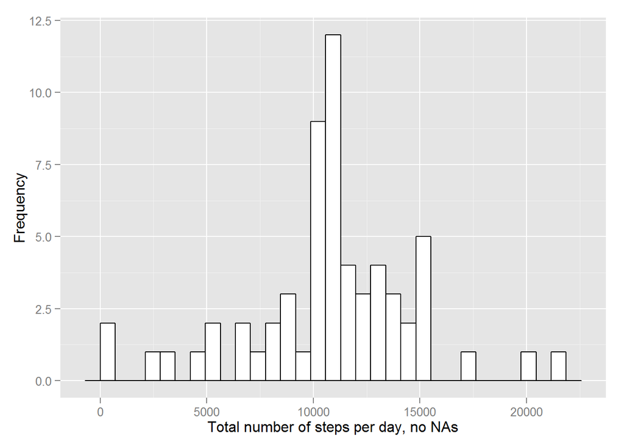

```r
ggplot(aes(x=totalsteps2), data=totalsteps_frame2)+
    geom_histogram(color="black", fill="white") + ylab("Frequency") + xlab("Total number of steps per day, no NAs")
```

**Mean and Median :**

```r
mean(totalsteps_frame2$totalsteps2)
```

```
## [1] 10766
```

```r
median(totalsteps_frame2$totalsteps2)
```

```
## [1] 10766
```

## Are there differences in activity patterns between weekdays and weekends?

New Factor Variables:

```r
# Find days of the week:
        data2$whatdayistoday<-weekdays(data2$date)
        str(data2)
```

```
## 'data.frame':    17568 obs. of  4 variables:
##  $ steps         : num  37.4 37.4 37.4 37.4 37.4 ...
##  $ date          : Date, format: "2012-10-01" "2012-10-01" ...
##  $ interval      : int  0 5 10 15 20 25 30 35 40 45 ...
##  $ whatdayistoday: chr  "Monday" "Monday" "Monday" "Monday" ...
```

```r
# Create variable:
        data2$day<-data2$whatdayistoday
        data2$day[data2$day=="Saturday" | data2$day=="Sunday"]<-"weekend"
        data2$day[data2$day != "weekend"]<-"weekday"
        str(data2)
```

```
## 'data.frame':    17568 obs. of  5 variables:
##  $ steps         : num  37.4 37.4 37.4 37.4 37.4 ...
##  $ date          : Date, format: "2012-10-01" "2012-10-01" ...
##  $ interval      : int  0 5 10 15 20 25 30 35 40 45 ...
##  $ whatdayistoday: chr  "Monday" "Monday" "Monday" "Monday" ...
##  $ day           : chr  "weekday" "weekday" "weekday" "weekday" ...
```

```r
# ok, but change to factors:
        data2$day<-as.factor(data2$day)
```

**Time Series Plot:**

```r
# Vector - mean weekdays:

        wds<-tapply(data2$steps[data2$day=="weekday"], data2$interval[data2$day=="weekday"], function(x)mean(x))
        mean_weekdays<-array(NA, c(length(wds),1))
        for(i in 1:length(wds)){
            mean_weekdays[i]<-wds[[i]]
}
head(mean_weekdays)
```

```
##       [,1]
## [1,] 7.007
## [2,] 5.384
## [3,] 5.140
## [4,] 5.162
## [5,] 5.073
## [6,] 6.295
```

```r
# Vector - mean weekends:

        wks<-tapply(data2$steps[data2$day=="weekend"], data2$interval[data2$day=="weekend"], function(x)mean(x))
        mean_weekends<-array(NA, c(length(wks),1))
        for(i in 1:length(wks)){
            mean_weekends[i]<-wks[[i]]
}
head(mean_weekends)
```

```
##       [,1]
## [1,] 4.673
## [2,] 4.673
## [3,] 4.673
## [4,] 4.673
## [5,] 4.673
## [6,] 7.923
```

```r
# Vector - interval from before = interval
# Dataset

        days_interval<-data.frame(interval, mean_weekdays, mean_weekends)
        str(days_interval)
```

```
## 'data.frame':    288 obs. of  3 variables:
##  $ interval     : int  0 5 10 15 20 25 30 35 40 45 ...
##  $ mean_weekdays: num  7.01 5.38 5.14 5.16 5.07 ...
##  $ mean_weekends: num  4.67 4.67 4.67 4.67 4.67 ...
```

**For multiple plots in a single window with ggplot, use function multiplot (available from cookbook-r).**

```r
multiplot <- function(..., plotlist=NULL, file, cols=1, layout=NULL) {
  require(grid)

  # Make a list from the ... arguments and plotlist
  plots <- c(list(...), plotlist)

  numPlots = length(plots)

  # If layout is NULL, then use 'cols' to determine layout
  if (is.null(layout)) {
 # Make the panel
 # ncol: Number of columns of plots
 # nrow: Number of rows needed, calculated from # of cols
    layout <- matrix(seq(1, cols * ceiling(numPlots/cols)),
                    ncol = cols, nrow = ceiling(numPlots/cols))
  }

 if (numPlots==1) {
    print(plots[[1]])

  } else {
 # Set up the page
    grid.newpage()
    pushViewport(viewport(layout = grid.layout(nrow(layout), ncol(layout))))

 # Make each plot, in the correct location
    for (i in 1:numPlots) {
      # Get the i,j matrix positions of the regions that contain this subplot
      matchidx <- as.data.frame(which(layout == i, arr.ind = TRUE))

      print(plots[[i]], vp = viewport(layout.pos.row = matchidx$row,
                                      layout.pos.col = matchidx$col))
    }
  }
}
```

**Time series for weekdays (top) and weekends (bottom):**

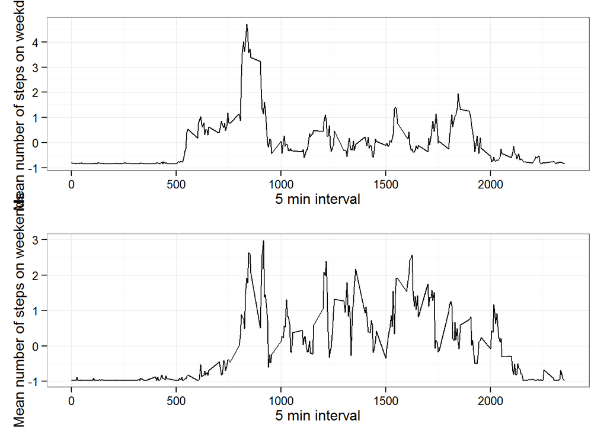

```r
        plot1<-ggplot(aes(x=interval, y=scale(mean_weekdays)), data=days_interval)+
            geom_line() + xlab("5 min interval") + ylab("Mean number of steps on weekdays") + theme_bw()

        plot2<-ggplot(aes(x=interval, y=scale(mean_weekends)), data=days_interval)+
            geom_line() + xlab("5 min interval") + ylab("Mean number of steps on weekends") + theme_bw()
        multiplot(plot1, plot2)
```